# Data Quality QA: NY School Enrollment

## Overview

This vignette performs data quality checks on New York State school enrollment data from 2012-2024. We examine:

```r
library(nyschooldata)
library(dplyr)
library(ggplot2)
library(scales)
```

## Fetch Multi-Year Data

We retrieve enrollment data for all available years (2012-2024).

```r
# Fetch district-level data for all available years
years <- 2012:2024

# Get enrollment data year by year (handles errors gracefully)
enr_all <- fetch_enr_years(years, level = "district", tidy = TRUE)
```

```
## Using cached data for 2012
```

```
## Using cached data for 2013
```

```
## Using cached data for 2014
```

```
## Using cached data for 2015
```

```
## Using cached data for 2016
```

```
## Using cached data for 2017
```

```
## Using cached data for 2018
```

```
## Using cached data for 2019
```

```
## Using cached data for 2020
```

```
## Using cached data for 2021
```

```
## Using cached data for 2022
```

```
## Using cached data for 2023
```

```
## Using cached data for 2024
```

```r
# Check what years we actually got
years_retrieved <- sort(unique(enr_all$end_year))
message("Years retrieved: ", paste(years_retrieved, collapse = ", "))
```

```
## Years retrieved: 2012, 2013, 2014, 2015, 2016, 2017, 2018, 2019, 2020, 2021, 2022, 2023, 2024
```

## Statewide Enrollment Trends

### Total State Enrollment by Year

```r
state_totals <- enr_all %>%
  filter(grade_level == "TOTAL") %>%
  group_by(end_year) %>%
  summarize(
    total_enrollment = sum(n_students, na.rm = TRUE),
    n_districts = n_distinct(district_code),
    .groups = "drop"
  ) %>%
  arrange(end_year) %>%
  mutate(
    yoy_change = total_enrollment - lag(total_enrollment),
    yoy_pct = yoy_change / lag(total_enrollment) * 100,
    flag_large_change = abs(yoy_pct) > 5
  )

state_totals
```

```
## # A tibble: 13 × 6
##    end_year total_enrollment n_districts yoy_change yoy_pct flag_large_change
##       <int>            <dbl>       <int>      <dbl>   <dbl> <lgl>
##  1     2012          2699840           1         NA NA      NA
##  2     2013          2680170           1     -19670 -0.729  FALSE
##  3     2014          2661609           1     -18561 -0.693  FALSE
##  4     2015          2655264           1      -6345 -0.238  FALSE
##  5     2016          2642186           1     -13078 -0.493  FALSE
##  6     2017          2623867           1     -18319 -0.693  FALSE
##  7     2018          2607282           1     -16585 -0.632  FALSE
##  8     2019          2577890           1     -29392 -1.13   FALSE
##  9     2020          2561821           1     -16069 -0.623  FALSE
## 10     2021          2455261           1    -106560 -4.16   FALSE
## 11     2022          2418631           1     -36630 -1.49   FALSE
## 12     2023          2403931         718     -14700 -0.608  FALSE
## 13     2024          2404319         718        388  0.0161 FALSE
```

### Identify Large Year-Over-Year Changes

Changes greater than 5% warrant investigation:

```r
large_changes <- state_totals %>%
  filter(flag_large_change == TRUE)

if (nrow(large_changes) > 0) {
  message("WARNING: Found ", nrow(large_changes), " year(s) with >5% enrollment change:")
  print(large_changes %>% select(end_year, total_enrollment, yoy_pct))
} else {
  message("No year-over-year changes exceeded 5% threshold")
}
```

```
## No year-over-year changes exceeded 5% threshold
```

### Statewide Trend Visualization

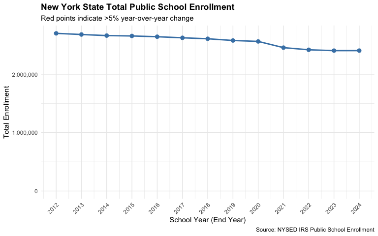

NY State Total Public School Enrollment

```r
ggplot(state_totals, aes(x = end_year, y = total_enrollment)) +
  geom_line(linewidth = 1, color = "steelblue") +
  geom_point(size = 2.5, color = "steelblue") +
  geom_point(
    data = state_totals %>% filter(flag_large_change),
    aes(x = end_year, y = total_enrollment),
    color = "red", size = 4
  ) +
  scale_y_continuous(labels = comma, limits = c(0, NA)) +
  scale_x_continuous(breaks = years_retrieved) +
  labs(
    title = "New York State Total Public School Enrollment",
    subtitle = "Red points indicate >5% year-over-year change",
    x = "School Year (End Year)",
    y = "Total Enrollment",
    caption = "Source: NYSED IRS Public School Enrollment"
  ) +
  theme_minimal() +
  theme(
    axis.text.x = element_text(angle = 45, hjust = 1),
    plot.title = element_text(face = "bold")
  )
```

### Year-Over-Year Percentage Change

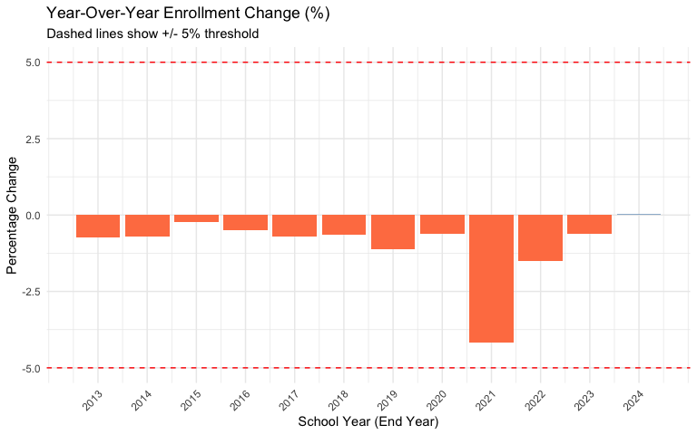

Year-over-year percentage change in enrollment

```r
ggplot(
  state_totals %>% filter(!is.na(yoy_pct)),
  aes(x = end_year, y = yoy_pct)
) +
  geom_col(
    aes(fill = yoy_pct > 0),
    show.legend = FALSE
  ) +
  geom_hline(yintercept = c(-5, 5), linetype = "dashed", color = "red") +
  scale_fill_manual(values = c("TRUE" = "steelblue", "FALSE" = "coral")) +
  scale_x_continuous(breaks = years_retrieved[-1]) +
  labs(
    title = "Year-Over-Year Enrollment Change (%)",
    subtitle = "Dashed lines show +/- 5% threshold",
    x = "School Year (End Year)",
    y = "Percentage Change"
  ) +
  theme_minimal() +
  theme(axis.text.x = element_text(angle = 45, hjust = 1))
```

## Major District Analysis

1. **NYC DOE** - New York City Department of Education (district code starting with “31”)
2. **Buffalo City SD** - Second largest district
3. **Rochester City SD** - Third largest district
4. **Yonkers Public Schools** - Fourth largest district
5. **Syracuse City SD** - Fifth largest district

```r
# Major district codes (first 6 digits of BEDS code)
major_districts <- tribble(
  ~district_code, ~district_label,
  "310200", "NYC DOE",
  "140600", "Buffalo City SD",
  "261600", "Rochester City SD",
  "662300", "Yonkers Public Schools",
  "421800", "Syracuse City SD"
)

# Note: NYC has multiple district_code prefixes (31xxxx)
# Let's identify the actual codes in our data

# Find NYC districts
nyc_districts <- enr_all %>%
  filter(is_nyc, grade_level == "TOTAL") %>%
  distinct(district_code, district_name) %>%
  head(5)

message("NYC district codes found:")
```

```
## NYC district codes found:
```

```r
print(nyc_districts)
```

```
##   district_code                 district_name
## 1        307500    NYC SPEC SCHOOLS - DIST 75
## 2        310100 NYC GEOG DIST # 1 - MANHATTAN
## 3        310200 NYC GEOG DIST # 2 - MANHATTAN
## 4        310300 NYC GEOG DIST # 3 - MANHATTAN
## 5        310400 NYC GEOG DIST # 4 - MANHATTAN
```

```r
# Find other major districts by name
all_districts <- enr_all %>%
  filter(grade_level == "TOTAL") %>%
  distinct(district_code, district_name)

# Search for our target districts
buffalo <- all_districts %>% filter(grepl("BUFFALO", toupper(district_name)))
rochester <- all_districts %>% filter(grepl("ROCHESTER", toupper(district_name)))
yonkers <- all_districts %>% filter(grepl("YONKERS", toupper(district_name)))
syracuse <- all_districts %>% filter(grepl("SYRACUSE", toupper(district_name)))

message("\nDistrict codes found:")
```

```
##
## District codes found:
```

```r
message("Buffalo: ", paste(buffalo$district_code, collapse = ", "))
```

```
## Buffalo: NA, 140600
```

```r
message("Rochester: ", paste(rochester$district_code, collapse = ", "))
```

```
## Rochester: NA, NA, 261313, 261600
```

```r
message("Yonkers: ", paste(yonkers$district_code, collapse = ", "))
```

```
## Yonkers: NA, 662300
```

```r
message("Syracuse: ", paste(syracuse$district_code, collapse = ", "))
```

```
## Syracuse: NA, NA, NA, 420303, 420401, 421800
```

### District-Level Enrollment Trends

```r
# Combine district codes for filtering
# NYC is special - aggregate all 31xxxx districts
target_districts <- c(
  buffalo$district_code[1],
  rochester$district_code[1],
  yonkers$district_code[1],
  syracuse$district_code[1]
)

# Get NYC aggregate
nyc_trend <- enr_all %>%
  filter(is_nyc, grade_level == "TOTAL") %>%
  group_by(end_year) %>%
  summarize(
    n_students = sum(n_students, na.rm = TRUE),
    .groups = "drop"
  ) %>%
  mutate(district_label = "NYC DOE")

# Get other major districts
other_trends <- enr_all %>%
  filter(
    district_code %in% target_districts,
    grade_level == "TOTAL"
  ) %>%
  select(end_year, district_name, n_students) %>%
  mutate(district_label = case_when(
    grepl("BUFFALO", toupper(district_name)) ~ "Buffalo City SD",
    grepl("ROCHESTER", toupper(district_name)) ~ "Rochester City SD",
    grepl("YONKERS", toupper(district_name)) ~ "Yonkers Public Schools",
    grepl("SYRACUSE", toupper(district_name)) ~ "Syracuse City SD",
    TRUE ~ district_name
  )) %>%
  select(end_year, district_label, n_students)

# Combine
district_trends <- bind_rows(nyc_trend, other_trends)

district_trends
```

```
## # A tibble: 7,932 × 3
##    end_year n_students district_label
##       <int>      <dbl> <chr>
##  1     2023     895097 NYC DOE
##  2     2024     898410 NYC DOE
##  3     2012       8495 ALBANY
##  4     2012        927 BERNE KNOX
##  5     2012       4936 BETHLEHEM
##  6     2012       2036 RAVENA COEYMANS
##  7     2012       1972 COHOES
##  8     2012       5231 SOUTH COLONIE
##  9     2012        256 MENANDS
## 10     2012       5512 NORTH COLONIE CSD
## # ℹ 7,922 more rows
```

### District Enrollment Visualization

[figure not shown]

```r
# Calculate YoY changes by district
district_yoy <- district_trends %>%
  arrange(district_label, end_year) %>%
  group_by(district_label) %>%
  mutate(
    yoy_pct = (n_students - lag(n_students)) / lag(n_students) * 100,
    flag_change = abs(yoy_pct) > 5
  ) %>%
  ungroup()

# Plot
ggplot(district_yoy, aes(x = end_year, y = n_students, color = district_label)) +
  geom_line(linewidth = 1) +
  geom_point(size = 2) +
  geom_point(
    data = district_yoy %>% filter(flag_change == TRUE),
    size = 4, shape = 1, stroke = 1.5
  ) +
  scale_y_continuous(labels = comma) +
  scale_x_continuous(breaks = years_retrieved) +
  scale_color_brewer(palette = "Set1") +
  labs(
    title = "Enrollment Trends: Major NY Districts",
    subtitle = "Circled points indicate >5% year-over-year change",
    x = "School Year (End Year)",
    y = "Total Enrollment",
    color = "District",
    caption = "Source: NYSED IRS Public School Enrollment"
  ) +
  theme_minimal() +
  theme(
    axis.text.x = element_text(angle = 45, hjust = 1),
    legend.position = "bottom"
  ) +
  guides(color = guide_legend(nrow = 2))
```

### District-Level Large Changes

```r
district_flags <- district_yoy %>%
  filter(flag_change == TRUE) %>%
  arrange(district_label, end_year) %>%
  select(district_label, end_year, n_students, yoy_pct)

if (nrow(district_flags) > 0) {
  message("Districts with >5% YoY changes:")
  print(district_flags)
} else {
  message("No major districts had >5% year-over-year changes")
}
```

```
## Districts with >5% YoY changes:
```

```
## # A tibble: 1,537 × 4
##    district_label end_year n_students yoy_pct
##    <chr>             <int>      <dbl>   <dbl>
##  1 AFTON              2017        513   -5.70
##  2 AFTON              2021        481   -7.85
##  3 AKRON              2021       1282   -7.50
##  4 ALBANY             2016       9625    6.00
##  5 ALBANY             2021       8853   -7.28
##  6 ALBION             2021       1783   -5.01
##  7 ALDEN              2021       1527   -6.43
##  8 ALEXANDER          2013        879   -5.89
##  9 ALEXANDER          2021        759   -7.66
## 10 ALEXANDRIA CSD     2015        574   -7.27
## # ℹ 1,527 more rows
```

### District Enrollment Table

```r
# Wide table of enrollment by district and year
district_wide <- district_trends %>%
  tidyr::pivot_wider(
    names_from = end_year,
    values_from = n_students
  )
district_wide
```

```
## # A tibble: 730 × 14
##    district_label `2023` `2024` `2012` `2013` `2014` `2015` `2016` `2017` `2018`
##    <chr>          <list> <list> <list> <list> <list> <list> <list> <list> <list>
##  1 NYC DOE        <dbl>  <dbl>  <NULL> <NULL> <NULL> <NULL> <NULL> <NULL> <NULL>
##  2 ALBANY         <NULL> <NULL> <dbl>  <dbl>  <dbl>  <dbl>  <dbl>  <dbl>  <dbl>
##  3 BERNE KNOX     <NULL> <NULL> <dbl>  <dbl>  <dbl>  <dbl>  <dbl>  <dbl>  <dbl>
##  4 BETHLEHEM      <NULL> <NULL> <dbl>  <dbl>  <dbl>  <dbl>  <dbl>  <dbl>  <dbl>
##  5 RAVENA COEYMA… <NULL> <NULL> <dbl>  <dbl>  <dbl>  <dbl>  <dbl>  <dbl>  <dbl>
##  6 COHOES         <NULL> <NULL> <dbl>  <dbl>  <dbl>  <dbl>  <dbl>  <dbl>  <dbl>
##  7 SOUTH COLONIE  <NULL> <NULL> <dbl>  <dbl>  <dbl>  <dbl>  <dbl>  <dbl>  <dbl>
##  8 MENANDS        <NULL> <NULL> <dbl>  <dbl>  <dbl>  <dbl>  <dbl>  <dbl>  <dbl>
##  9 NORTH COLONIE… <NULL> <NULL> <dbl>  <dbl>  <dbl>  <dbl>  <dbl>  <dbl>  <dbl>
## 10 GREEN ISLAND   <NULL> <NULL> <dbl>  <dbl>  <dbl>  <dbl>  <dbl>  <dbl>  <dbl>
## # ℹ 720 more rows
## # ℹ 4 more variables: `2019` <list>, `2020` <list>, `2021` <list>,
## #   `2022` <list>
```

## Data Completeness Checks

### Missing Data by Year

```r
missing_summary <- enr_all %>%
  filter(grade_level == "TOTAL") %>%
  group_by(end_year) %>%
  summarize(
    n_districts = n_distinct(district_code),
    n_missing_enrollment = sum(is.na(n_students)),
    pct_missing = n_missing_enrollment / n() * 100,
    .groups = "drop"
  )

missing_summary
```

```
## # A tibble: 13 × 4
##    end_year n_districts n_missing_enrollment pct_missing
##       <int>       <int>                <int>       <dbl>
##  1     2012           1                    0           0
##  2     2013           1                    0           0
##  3     2014           1                    0           0
##  4     2015           1                    0           0
##  5     2016           1                    0           0
##  6     2017           1                    0           0
##  7     2018           1                    0           0
##  8     2019           1                    0           0
##  9     2020           1                    0           0
## 10     2021           1                    0           0
## 11     2022           1                    0           0
## 12     2023         718                    0           0
## 13     2024         718                    0           0
```

### Grade-Level Data Availability

Check which grade levels are available across years:

```r
grade_avail <- enr_all %>%
  group_by(end_year, grade_level) %>%
  summarize(
    n_records = n(),
    n_with_data = sum(!is.na(n_students)),
    .groups = "drop"
  ) %>%
  filter(grade_level %in% c("TOTAL", "K", "01", "05", "09", "12"))

tidyr::pivot_wider(
  grade_avail,
  id_cols = end_year,
  names_from = grade_level,
  values_from = n_with_data
)
```

```
## # A tibble: 13 × 7
##    end_year  `01`  `05`  `09`  `12` TOTAL     K
##       <int> <int> <int> <int> <int> <int> <int>
##  1     2012   726   726   726   726   726    NA
##  2     2013   723   723   723   723   723    NA
##  3     2014   721   721   721   721   721    NA
##  4     2015   721   721   721   721   721    NA
##  5     2016   721   721   721   721   721    NA
##  6     2017   721   721   721   721   721    NA
##  7     2018   721   721   721   721   721    NA
##  8     2019   721   721   721   721   721    NA
##  9     2020   719   719   719   719   719    NA
## 10     2021   718   718   718   718   718    NA
## 11     2022   718   718   718   718   718    NA
## 12     2023   718   718   718   718   718   718
## 13     2024   718   718   718   718   718   718
```

## Data Quality Issues Found

Based on the analysis above, document any issues:

```r
issues <- list()

# Check for years with large statewide changes
if (nrow(large_changes) > 0) {
  issues$statewide_jumps <- large_changes$end_year
}

# Check for district-level anomalies
if (nrow(district_flags) > 0) {
  issues$district_anomalies <- district_flags
}

# Check for missing data
high_missing <- missing_summary %>% filter(pct_missing > 1)
if (nrow(high_missing) > 0) {
  issues$high_missing_years <- high_missing$end_year
}

# Print summary
message("\n=== DATA QUALITY SUMMARY ===\n")
```

```
##
## === DATA QUALITY SUMMARY ===
```

```r
if (length(issues) == 0) {
  message("No significant data quality issues identified.")
} else {
  if (!is.null(issues$statewide_jumps)) {
    message("Statewide enrollment jumps (>5%) in years: ",
            paste(issues$statewide_jumps, collapse = ", "))
  }
  if (!is.null(issues$district_anomalies)) {
    message("\nDistrict-level anomalies:")
    print(issues$district_anomalies)
  }
  if (!is.null(issues$high_missing_years)) {
    message("\nYears with >1% missing data: ",
            paste(issues$high_missing_years, collapse = ", "))
  }
}
```

```
##
## District-level anomalies:
```

```
## # A tibble: 1,537 × 4
##    district_label end_year n_students yoy_pct
##    <chr>             <int>      <dbl>   <dbl>
##  1 AFTON              2017        513   -5.70
##  2 AFTON              2021        481   -7.85
##  3 AKRON              2021       1282   -7.50
##  4 ALBANY             2016       9625    6.00
##  5 ALBANY             2021       8853   -7.28
##  6 ALBION             2021       1783   -5.01
##  7 ALDEN              2021       1527   -6.43
##  8 ALEXANDER          2013        879   -5.89
##  9 ALEXANDER          2021        759   -7.66
## 10 ALEXANDRIA CSD     2015        574   -7.27
## # ℹ 1,527 more rows
```

## Recommendations

Based on this QA analysis:

1. **Statewide trends**: Review any years flagged with >5% changes to determine if they represent genuine enrollment shifts or data collection issues.
2. **District analysis**: Major urban districts (NYC, Buffalo, Rochester, Yonkers, Syracuse) should be monitored for unusual year-over-year changes.
3. **Data completeness**: Years with high missing data rates may need special handling in analyses.